# Sales

Author

Ethan Chan, Alex Back, Darren Kuboyama

Published

December 11, 2024

**Scientific Question: How do customer engagement metrics, sentiments, and feedback patterns relate to product performance and differentiate top-rated from bottom-rated products across categories?**

We begin by adding the tidyverse library for later uses.

#Packages

```r
library(tidyverse)
library(tidytext)
```

Next we read in the product information into a dataframe and then combine all the review csvs into one single dataframe to later data clean.

```r
product_info <- read.csv('product_info.csv')
review_files <- list.files(pattern = "reviews_.*\\.csv") #merge csvs
reviews <- do.call(rbind, lapply(review_files, read.csv)) #make it into a dataframe
```

Now we narrow it down to the metrics we want to look at, specifically the categories, reviews, ratings, and loves count.

```r
product_data <- product_info %>%
  select(product_id, product_name, brand_id, primary_category, secondary_category, tertiary_category, rating, reviews, loves_count) %>%
  filter(!(secondary_category == "" & tertiary_category == ""))
```

Now we sort them into the top 3 and worst 3 based on the secondary category.

```r
top_3 <- product_data %>%
  group_by(secondary_category) %>%
  arrange(desc(rating), desc(reviews), desc(loves_count)) %>%
  slice_head(n = 3) %>%
  ungroup()

worst_3 <- product_data %>%
  group_by(secondary_category) %>%
  arrange(rating, reviews, loves_count) %>%
  slice_head(n = 3) %>%
  ungroup()

combined <- bind_rows(
  top_3 %>% mutate(category = "Top 3"),
  worst_3 %>% mutate(category = "Worst 3")
)
```

Now we might look at some trends, lets look at the average rating, reviews, and loves of the top 3 and worst 3.

```r
# Combined summary for Top 3 and Worst 3
summary_overall <- combined %>%
  group_by(category) %>%
  summarize(
    avg_rating = mean(rating, na.rm = TRUE),
    avg_reviews = mean(reviews, na.rm = TRUE),
    avg_loves = mean(loves_count, na.rm = TRUE)
  )

summary_category <- combined %>%
  group_by(secondary_category, category) %>%
  summarize(
    avg_rating = mean(rating, na.rm = TRUE),
    avg_reviews = mean(reviews, na.rm = TRUE),
    avg_loves = mean(loves_count, na.rm = TRUE),
    .groups = "drop"
  )
```

We can now start comparing the rating, reviews, and love counts for the top 3 and bottom 3 products of each category by looking at some graphs.

#Graphs

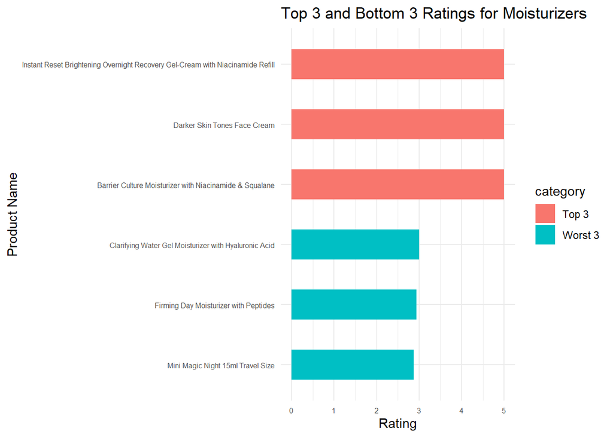

```r
top_bottom_moisturizers <- combined %>%
  filter(secondary_category == "Moisturizers") %>%
  filter(category %in% c("Top 3", "Worst 3"))  # Grab Top 3 and Worst 3

ggplot(top_bottom_moisturizers, aes(x = reorder(product_name, rating), y = rating, fill = category)) +
  geom_bar(stat = "identity", width = 0.5) +
  labs(
    title = "Top 3 and Bottom 3 Ratings for Moisturizers",
    x = "Product Name",
    y = "Rating"
  ) +
  coord_flip() +  # flip the axis for better visibility
  theme_minimal() +
  theme(
    axis.text.y = element_text(size = 6),
    axis.text.x = element_text(size = 6)
  )
```

An important detail we can see just from visualizing the product names in this graph is that popular ingredients like Hyaluronic Acid do not guarantee high ratings. In fact, this product falls under the Worst 3 category. In contrast, ingredients like Niacinamide or products that target dark spots and the skin’s texture seem to dominate the Top 3.

Now lets narrow this down to gain a deeper understanding of the metrics’ correlations. From this, we will have a deeper understanding of whether or not high ratings are linked to customer engagement. Furthermore, the relationship between these metrics could identify strengths or weaknesses in a company’s product.

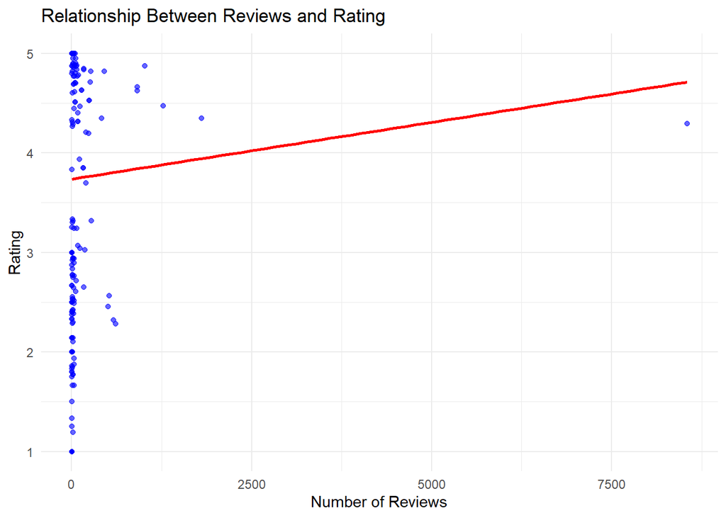

```r
# Scatterplot: Rating vs Reviews
ggplot(combined, aes(x = reviews, y = rating)) +
  geom_point(alpha = 0.6, color = "blue") +
  geom_smooth(method = "lm", se = FALSE, color = "red") +
  labs(
    title = "Relationship Between Reviews and Rating",
    x = "Number of Reviews",
    y = "Rating"
  ) +
  theme_minimal()
```

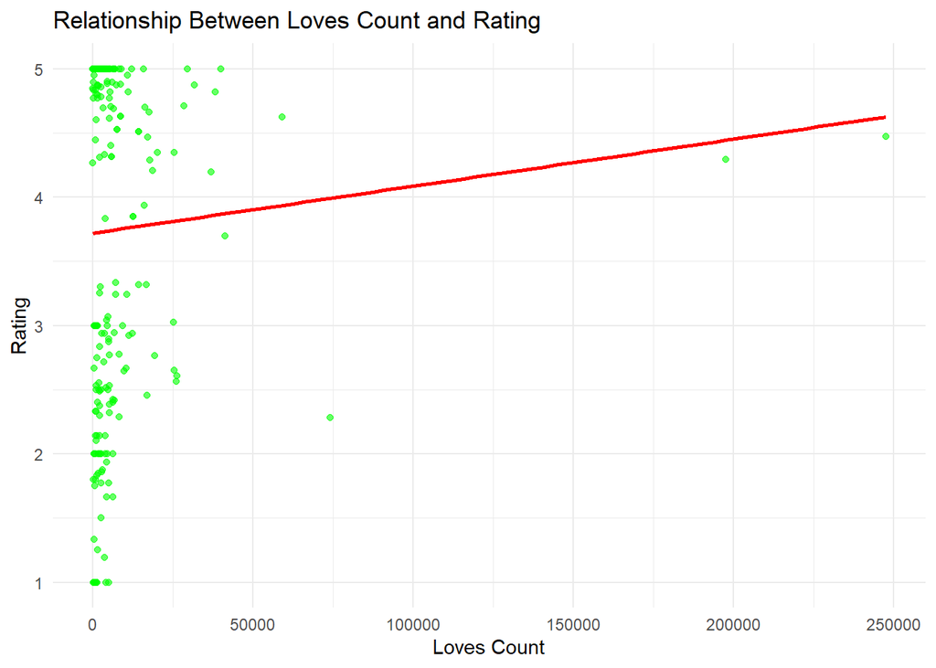

```r
# Scatterplot: Rating vs Loves Count
ggplot(combined, aes(x = loves_count, y = rating)) +
  geom_point(alpha = 0.6, color = "green") +
  geom_smooth(method = "lm", se = FALSE, color = "red") +
  labs(
    title = "Relationship Between Loves Count and Rating",
    x = "Loves Count",
    y = "Rating"
  ) +
  theme_minimal()
```

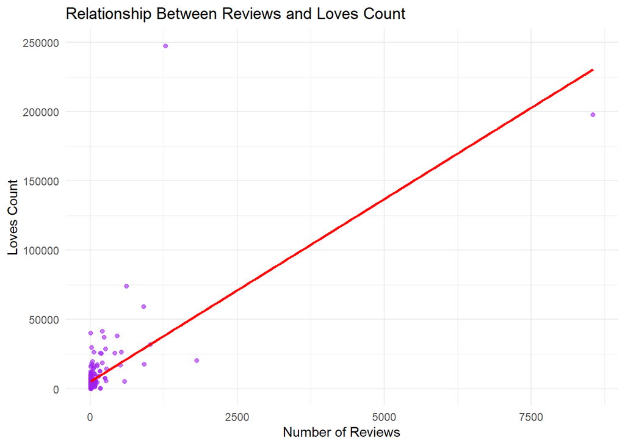

```r
# Scatterplot: Loves Count vs Reviews
ggplot(combined, aes(x = reviews, y = loves_count)) +
  geom_point(alpha = 0.6, color = "purple") +
  geom_smooth(method = "lm", se = FALSE, color = "red") +
  labs(
    title = "Relationship Between Reviews and Loves Count",
    x = "Number of Reviews",
    y = "Loves Count"
  ) +
  theme_minimal()
```

The third plot, examining the relationship between reviews and loves, shows a strong positive correlation. This indicates that products with higher reviews also tend to have higher loves, suggesting that customer interactions through reviews align closely with emotional resonance and loyalty. Loves reflects a product’s desirability and brand appeal, while reviews showcase customer engagement and feedback. Products that perform well in both metrics demonstrate strong marketing and customer alignment.

Quantitatively, the correlation between reviews and loves is significantly stronger compared to the relationships between reviews and ratings or ratings and loves. This suggests that products with higher reviews are not only engaging customers, but are also more likely to be loved, making the combination of these metrics a holistic indicator of product performance.

We can also observe this with a correlation table:

```r
# Correlations of Metrics Across Secondary Categories
correlations <- combined %>%
  group_by(secondary_category) %>%
  summarize(
    corr_reviews_rating = cor(reviews, rating, use = "complete.obs"),
    corr_rating_loves = cor(rating, loves_count, use = "complete.obs"),
    corr_reviews_loves = cor(reviews, loves_count, use = "complete.obs"),
    .groups = "drop"
  )
correlations
```

```
# A tibble: 41 × 4
   secondary_category   corr_reviews_rating corr_rating_loves corr_reviews_loves
   <chr>                              <dbl>             <dbl>              <dbl>
 1 Accessories                      -0.135            -0.147               0.966
 2 Bath & Body                      -0.0480           -0.0693              0.992
 3 Bath & Shower                    -0.714            -0.280               0.428
 4 Beauty Accessories                0.287             0.217               0.513
 5 Beauty Supplements                1                 1                   1
 6 Beauty Tools                      0.668             0.460               0.792
 7 Body Care                         0.887             0.763               0.906
 8 Body Moisturizers                 0.641             0.207               0.218
 9 Brushes & Applicato…             -0.0786            0.673               0.109
10 Candles & Home Scen…              0.481             0.263               0.831
# ℹ 31 more rows
```

```r
summary_metrics <- combined %>%
  group_by(category) %>%
  summarize(
    avg_rating = mean(rating, na.rm = TRUE),
    avg_reviews = mean(reviews, na.rm = TRUE),
    avg_loves = mean(loves_count, na.rm = TRUE),
    .groups = "drop"
  )
print(summary_metrics)
```

```
# A tibble: 2 × 4
  category avg_rating avg_reviews avg_loves
  <chr>         <dbl>       <dbl>     <dbl>
1 Top 3          4.90        67.9     7617.
2 Worst 3        2.59       133.      8089.
```

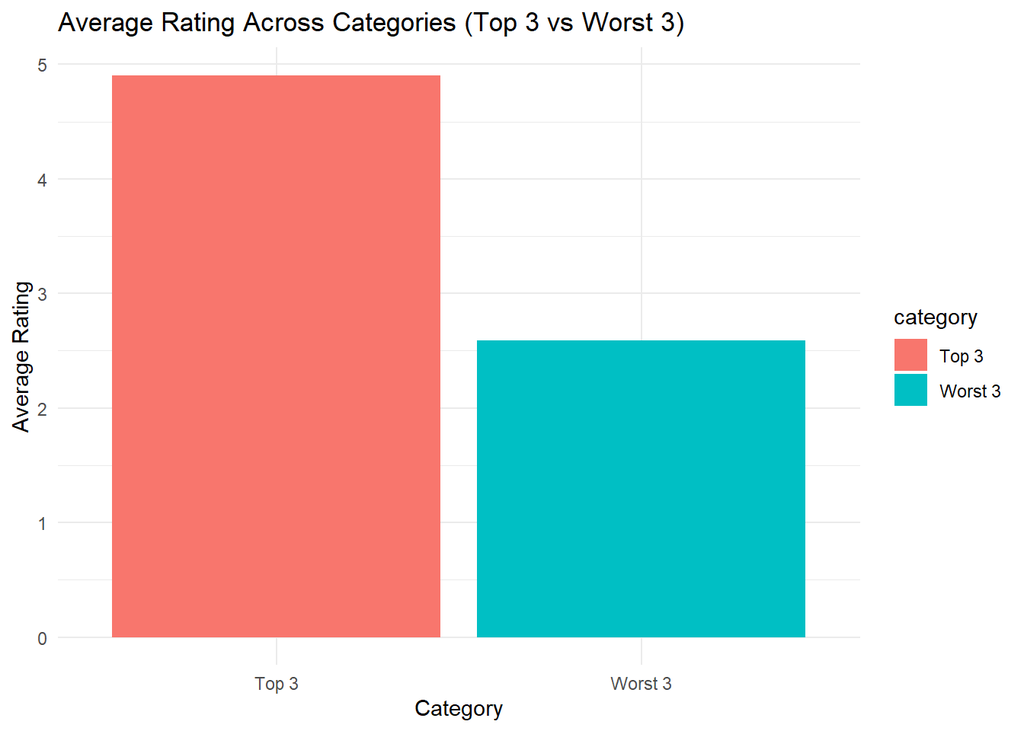

```r
# Barplot: Ratings Across Categories
ggplot(summary_metrics, aes(x = category, y = avg_rating, fill = category)) +
  geom_bar(stat = "identity") +
  labs(
    title = "Average Rating Across Categories (Top 3 vs Worst 3)",
    x = "Category",
    y = "Average Rating"
  ) +
  theme_minimal()
```

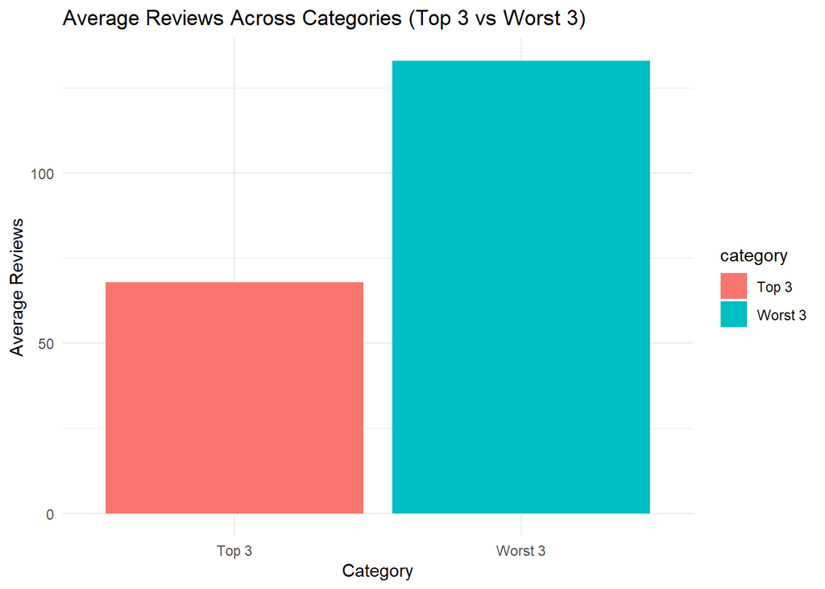

```r
# Barplot: Reviews Across Categories
ggplot(summary_metrics, aes(x = category, y = avg_reviews, fill = category)) +
  geom_bar(stat = "identity") +
  labs(
    title = "Average Reviews Across Categories (Top 3 vs Worst 3)",
    x = "Category",
    y = "Average Reviews"
  ) +
  theme_minimal()
```

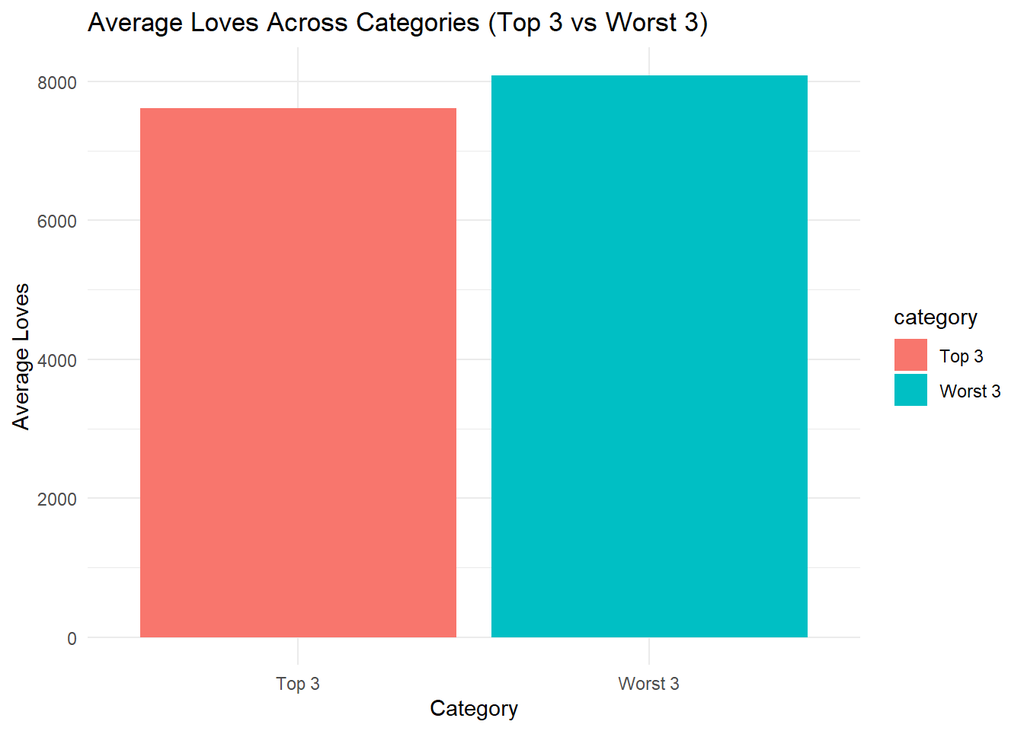

```r
# Barplot: Loves Across Categories
ggplot(summary_metrics, aes(x = category, y = avg_loves, fill = category)) +
  geom_bar(stat = "identity") +
  labs(
    title = "Average Loves Across Categories (Top 3 vs Worst 3)",
    x = "Category",
    y = "Average Loves"
  ) +
  theme_minimal()
```

To further analyze the differences in the average ratings, reviews, and loves count between the top 3 and worst 3 products, we represented this through a table and separate bar plots. From this collection of data, we can assess how customer engagement, satisfaction, and loyalty differ for each category.

The first bar plot focuses on the relationship between the average rating across the top 3 and worst 3 products. While the worst 3 products have an average rating of around 2.59, the top 3 products nearly double that with an average rating of 4.90.

The second bar plot examines the relationship between the average reviews across the top 3 and worst 3 products. Within the top 3 products, the average reviews is around 67.89 reviews and for the worst 3 products, the average reviews is much higher around 132.96 reviews.

The third bar plot highlights the relationship between the average loves across the top 3 and worst 3 products. For both the top 3 and worst 3 products, the average love counts stays relatively the same with the top 3 having an average of 7616.66 loves and the worst 3 having an average of 8088.73 loves.

When analyzing these plots, we observed that the top 3 and worst 3 products have significantly different average ratings and reviews. While the top 3 products have higher average ratings, they also retain fewer average reviews and loves. This suggests that high visibility and customer engagement (through reviews) don’t always translate to positive sentiments or high ratings. Instead, these metrics could indicate polarizing products that attract significant attention but also receive mixed or negative feedback. However, despite the top 3 products having fewer reviews and loves, they are still able to maintain a higher average rating, implying consistent quality and satisfaction to a smaller, and perhaps more loyal group of customers.

Furthermore, this observation could enforce the idea that the quantity of engagement through reviews or loves does not necessarily equate to the quality of sentiment through ratings. Understanding this dynamic could assist brands to focus on improving their underperforming products with high visibility and transform them into something that can also sustain customer loyalty and satisfaction.

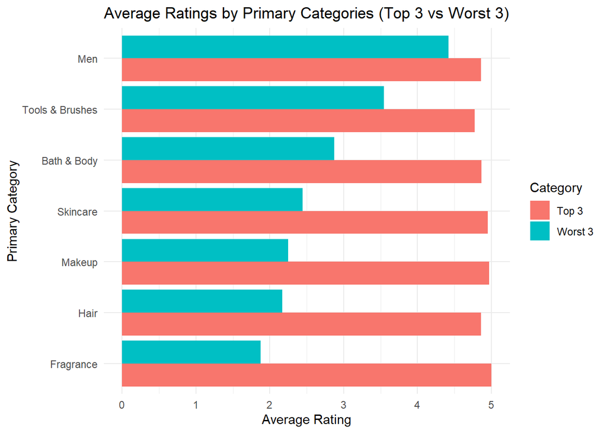

```r
broad_category_summary <- combined %>%
  filter(primary_category != "Mini Size") %>%
  mutate(
    broad_category = ifelse(is.na(primary_category) | primary_category == "", "Other", primary_category)
  ) %>%
  group_by(broad_category, category) %>%
  summarize(
    avg_rating = mean(rating, na.rm = TRUE),
    avg_reviews = mean(reviews, na.rm = TRUE),
    avg_loves = mean(loves_count, na.rm = TRUE),
    .groups = "drop"
  )

# Barplot: Average Ratings vs. Primary Category
ggplot(broad_category_summary, aes(x = reorder(broad_category, avg_rating), y = avg_rating, fill = category)) +
  geom_bar(stat = "identity", position = "dodge") +
  coord_flip() +
  labs(
    title = "Average Ratings by Primary Categories (Top 3 vs Worst 3)",
    x = "Primary Category",
    y = "Average Rating",
    fill = "Category"
  ) +
  theme_minimal()
```

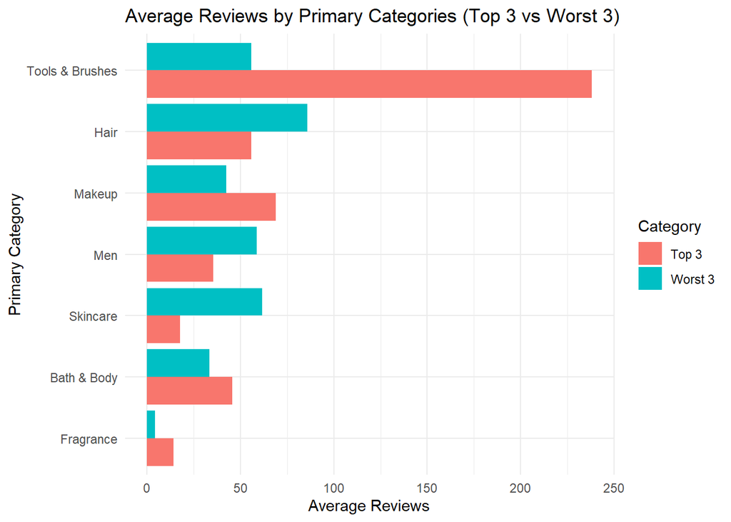

```r
# Barplot: Average Reviews vs. Primary Categories
ggplot(broad_category_summary, aes(x = reorder(broad_category, avg_reviews), y = avg_reviews, fill = category)) +
  geom_bar(stat = "identity", position = "dodge") +
  coord_flip() +
  labs(
    title = "Average Reviews by Primary Categories (Top 3 vs Worst 3)",
    x = "Primary Category",
    y = "Average Reviews",
    fill = "Category"
  ) +
  theme_minimal()
```

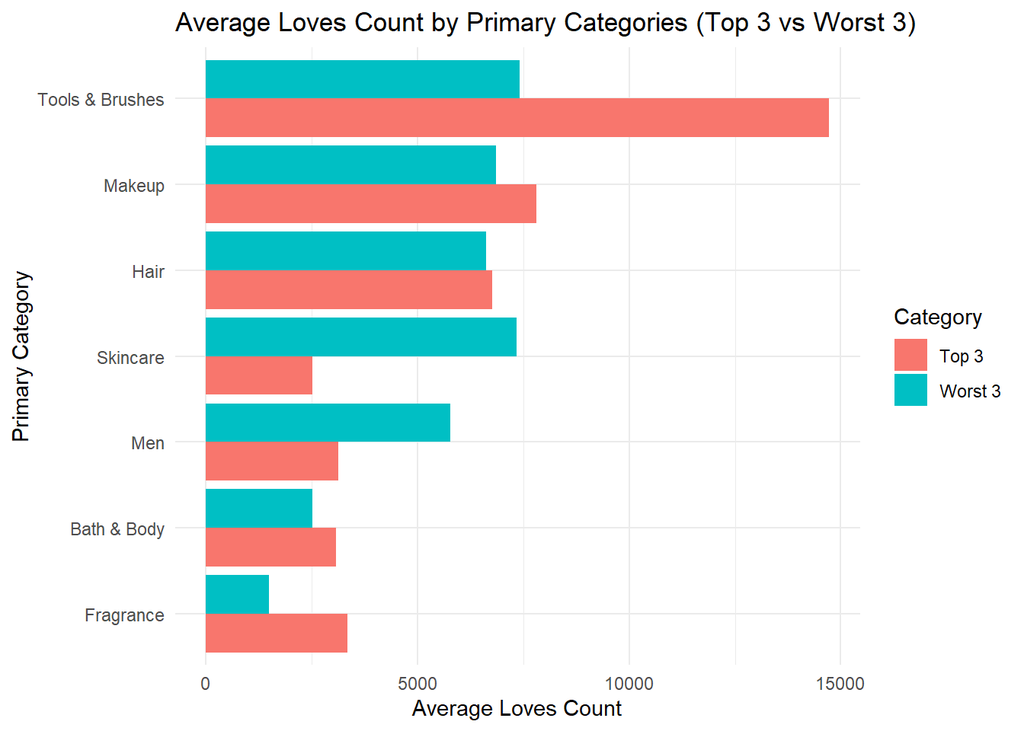

```r
# Barplot: Average Loves Count vs. Primary Categories
ggplot(broad_category_summary, aes(x = reorder(broad_category, avg_loves), y = avg_loves, fill = category)) +
  geom_bar(stat = "identity", position = "dodge") +
  coord_flip() +
  labs(
    title = "Average Loves Count by Primary Categories (Top 3 vs Worst 3)",
    x = "Primary Category",
    y = "Average Loves Count",
    fill = "Category"
  ) +
  theme_minimal()
```

To better understand the performance of products across primary categories, we analyzed the data based on average ratings, reviews, and loves count for the top 3 and bottom 3 products. Mini-sized products were excluded from this analysis to ensure the results focused on the full-sized offerings, as mini sizes might skew the findings without offering unique insights.

The results reveal several key trends. In skincare, the worst 3 products surprisingly received higher reviews and loves compared to the top 3 products. This suggests that skincare products in the worst-performing group still garner significant customer interest but likely fail to meet expectations in terms of quality or effectiveness. This pattern could point to either high demand for these products, driven by strong marketing or desirable features, or simply a broader audience that ended up being dissatisfied with the results. This highlights the importance of investigating variability within this category, as high engagement does not necessarily translate to high satisfaction.

Other categories, such as Makeup, Hair, and Bath & Body, reveal more mixed patterns, where engagement levels and satisfaction are not always aligned. For example, some products in these categories have high reviews or loves counts but still fall into the bottom 3 due to lower ratings. This indicates that polarizing preferences or niche appeals might influence customer perceptions, with some consumers finding these products highly satisfactory while others are left disappointed. Fragrance, in particular, shows lower overall reviews and loves for both top and bottom performers, reflecting its position as a more specialized category catering to a specific audience.

These findings emphasize the complex dynamics between engagement, loyalty, and satisfaction. While reviews and loves counts provide valuable insights into customer interest and emotional connection to products, they do not always correlate directly with ratings, which reflect overall satisfaction and quality. Skincare, for instance, underscores the need for brands to explore why high customer interest does not always lead to high satisfaction. On the other hand, the consistent performance of Tools & Brushes highlights the importance of quality in driving positive outcomes.

To gain a more nuanced understanding of these trends, it is essential to dive deeper into customer review sentiments. This would help uncover the specific reasons behind high engagement yet low satisfaction in certain categories and identify potential areas for improvement. Additionally, leveraging the success of consistently high-performing categories like Tools & Brushes could provide valuable insights into how other categories might enhance their appeal and performance. Understanding these patterns will allow brands to refine their strategies, improve underperforming products, and build on the strengths of their most successful offerings.

Now lets move onto reviews:

```r
reviews_filtered <- reviews %>%
  filter(product_id %in% combined$product_id) %>%
  select(product_id, review_text, is_recommended, helpfulness, total_feedback_count, total_neg_feedback_count, total_pos_feedback_count)

reviews_cleaned <- reviews_filtered %>%
  filter(!is.na(review_text) & review_text != "") %>%
  unnest_tokens(word, review_text) %>%
  filter(str_detect(word, "[a-zA-Z']")) %>%
  mutate(word = tolower(word)) %>%
  anti_join(stop_words, by = "word")

review_sentiments <- reviews_cleaned %>%
  inner_join(get_sentiments("bing"), by = "word") %>%
  count(product_id, sentiment) %>%
  pivot_wider(names_from = sentiment, values_from = n, values_fill = 0) %>%
  mutate(
    sentiment_score = positive - negative,
    sentiment_ratio = positive / (positive + negative + 1)
  )
```

```r
# Join sentiment scores with filtered reviews
reviews_with_sentiments <- reviews_filtered %>%
  left_join(review_sentiments, by = "product_id")  # Add sentiment data

# Summarize sentiment with additional metrics
review_summary <- reviews_with_sentiments %>%
  group_by(product_id) %>%
  summarize(
    avg_sentiment = mean(sentiment_score, na.rm = TRUE),  # Use sentiment_score directly
    avg_helpfulness = mean(helpfulness, na.rm = TRUE),
    avg_total_feedback = mean(total_feedback_count, na.rm = TRUE),
    avg_positive_feedback = mean(total_pos_feedback_count, na.rm = TRUE),
    avg_negative_feedback = mean(total_neg_feedback_count, na.rm = TRUE),
    avg_is_recommended = mean(as.numeric(is_recommended), na.rm = TRUE),  # Convert logical to numeric
    .groups = "drop"
  )
```

```r
combined_sentiment <- combined %>%
    left_join(review_summary, by = "product_id") %>%
    drop_na(avg_sentiment, rating) %>%
    filter(is.finite(avg_sentiment), is.finite(rating))

combined_sentiment <- combined_sentiment %>%
    filter(!is.na(avg_helpfulness), !is.na(avg_sentiment)) %>%
    filter(is.finite(avg_helpfulness), is.finite(avg_sentiment))

summary_by_category <- combined_sentiment %>%
  group_by(category) %>%
  summarize(
    avg_rating = mean(rating, na.rm = TRUE),
    avg_sentiment = mean(avg_sentiment, na.rm = TRUE),
    avg_helpfulness = mean(avg_helpfulness, na.rm = TRUE),
    avg_total_feedback = mean(avg_total_feedback, na.rm = TRUE),
    avg_positive_feedback = mean(avg_positive_feedback, na.rm = TRUE),
    avg_negative_feedback = mean(avg_negative_feedback, na.rm = TRUE),
    avg_is_recommended = mean(avg_is_recommended, na.rm = TRUE),
    .groups = "drop"
  )

# View summary
print(summary_by_category)
```

```
# A tibble: 2 × 8
  category avg_rating avg_sentiment avg_helpfulness avg_total_feedback
  <chr>         <dbl>         <dbl>           <dbl>              <dbl>
1 Top 3          4.95          51             0.791               7.67
2 Worst 3        2.44          -5.3           0.781               9.49
# ℹ 3 more variables: avg_positive_feedback <dbl>, avg_negative_feedback <dbl>,
#   avg_is_recommended <dbl>
```

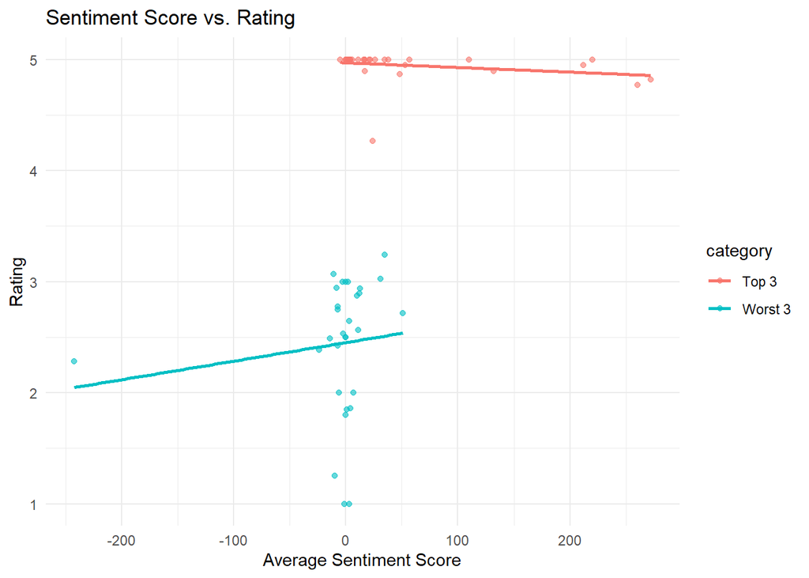

```r
ggplot(combined_sentiment, aes(x = avg_sentiment, y = rating, color = category)) +
  geom_point(alpha = 0.6) +
  geom_smooth(method = "lm", se = FALSE) +
  labs(
    title = "Sentiment Score vs. Rating",
    x = "Average Sentiment Score",
    y = "Rating"
  ) +
  theme_minimal()
```

This graph illustrates the relationship between sentiment score and product rating, distinguishing between the top 3 and worst 3 products. The top 3 products reveal consistently high ratings (close to 5) and positive sentiment scores, indicating strong alignment between customer satisfaction and emotional responses. In contrast, the worst 3 products display more variability, with lower ratings and wider ranges of sentiment scores. While positive sentiment generally correlates with higher ratings, the variability in sentiment for poorly rated products suggests dissatisfaction or unmet expectations. This comparison highlights how sentiment analysis complements ratings in identifying customer perceptions of product effectiveness.

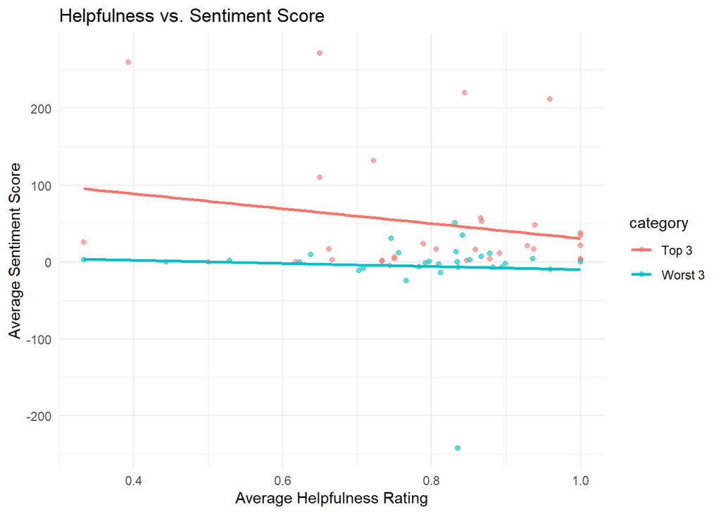

```r
ggplot(combined_sentiment, aes(x = avg_helpfulness, y = avg_sentiment, color = category)) +
  geom_point(alpha = 0.6) +
  geom_smooth(method = "lm", se = FALSE) +
  labs(
    title = "Helpfulness vs. Sentiment Score",
    x = "Average Helpfulness Rating",
    y = "Average Sentiment Score"
  ) +
  theme_minimal()
```

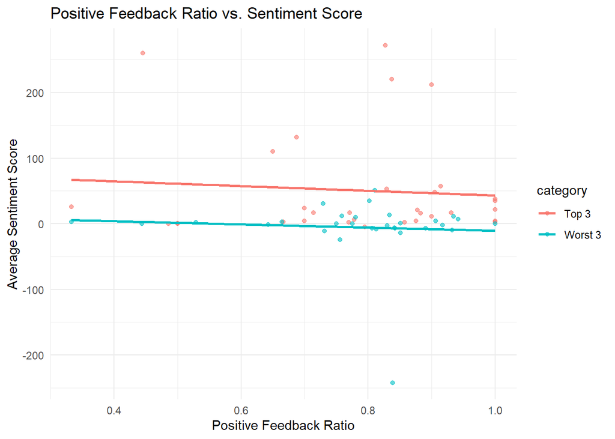

```r
combined_sentiment <- combined_sentiment %>%
  mutate(feedback_ratio = avg_positive_feedback / avg_total_feedback)

ggplot(combined_sentiment, aes(x = feedback_ratio, y = avg_sentiment, color = category)) +
  geom_point(alpha = 0.6) +
  geom_smooth(method = "lm", se = FALSE) +
  labs(
    title = "Positive Feedback Ratio vs. Sentiment Score",
    x = "Positive Feedback Ratio",
    y = "Average Sentiment Score"
  ) +
  theme_minimal()
```

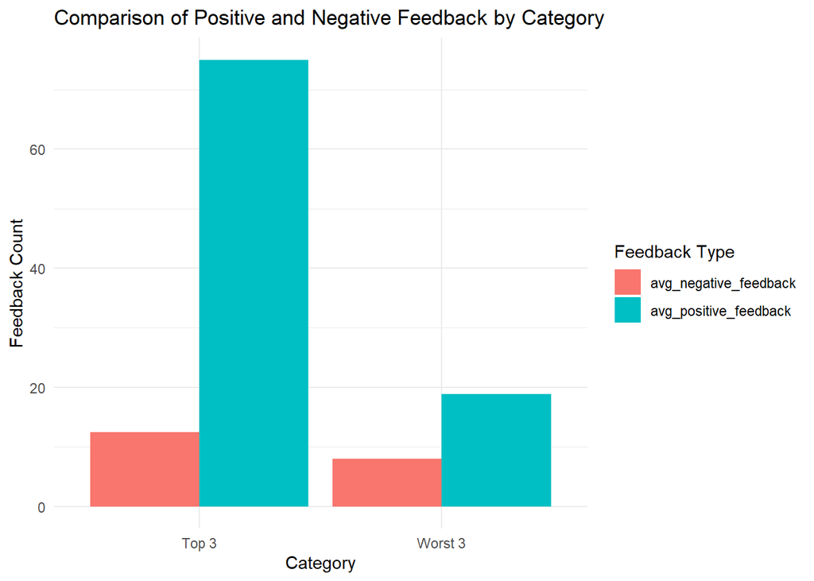

```r
feedback_data <- combined_sentiment %>%
  gather(key = "feedback_type", value = "feedback_count", avg_positive_feedback, avg_negative_feedback)

ggplot(feedback_data, aes(x = category, y = feedback_count, fill = feedback_type)) +
  geom_bar(stat = "identity", position = "dodge") +
  labs(
    title = "Comparison of Positive and Negative Feedback by Category",
    x = "Category",
    y = "Feedback Count",
    fill = "Feedback Type"
  ) +
  theme_minimal()
```

```r
combined_sentiment <- combined_sentiment %>%
  mutate(feedback_ratio = avg_positive_feedback / avg_total_feedback)

model <- lm(rating ~ avg_sentiment + avg_helpfulness + feedback_ratio + category, data = combined_sentiment)

summary(model)
```

```
Call:
lm(formula = rating ~ avg_sentiment + avg_helpfulness + feedback_ratio +
    category, data = combined_sentiment)

Residuals:
     Min       1Q   Median       3Q      Max
-1.34619 -0.04173  0.01671  0.20273  0.80061

Coefficients:
                  Estimate Std. Error t value Pr(>|t|)
(Intercept)      4.6772078  0.3056030  15.305   <2e-16 ***
avg_sentiment    0.0001024  0.0008840   0.116    0.908
avg_helpfulness -0.3160607  0.8648176  -0.365    0.716
feedback_ratio   0.6619612  0.8415924   0.787    0.435
categoryWorst 3 -2.5062432  0.1235745 -20.281   <2e-16 ***
---
Signif. codes:  0 '***' 0.001 '**' 0.01 '*' 0.05 '.' 0.1 ' ' 1

Residual standard error: 0.439 on 57 degrees of freedom
Multiple R-squared:  0.8988,    Adjusted R-squared:  0.8917
F-statistic: 126.6 on 4 and 57 DF,  p-value: < 2.2e-16
```

To quantify these relationships, we performed a linear regression analysis. The model predicts product ratings based on average sentiment, helpfulness, feedback ratio, and category. The results showed that while sentiment scores and feedback ratios alone were not statistically significant predictors, the distinction between top 3 and worst 3 categories was highly significant. Products in the worst 3 categories, on average, had ratings about 2.5 points lower than those in the top 3. This highlights that category plays a critical role in differentiating product performance.

The model itself had a high R-squared value of 0.89, meaning it explains about 89% of the variance in product ratings, showing that our chosen predictors together provide a strong explanation of product performance.